# Lab 2 - Intro to Data

Key

Week 2

#### Exercise 1:

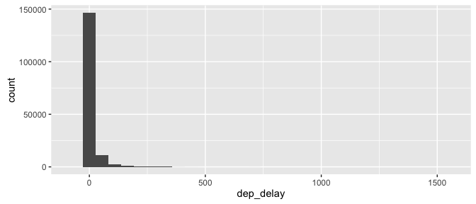

```r
qplot(x = dep_delay, data = flights, geom = "histogram")
```

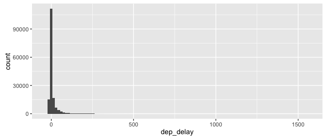

```r
qplot(x = dep_delay, data = flights, geom = "histogram", binwidth = 15)
```

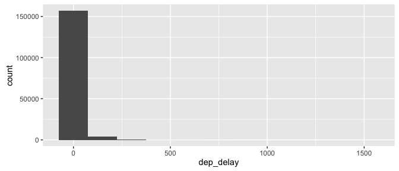

```r
qplot(x = dep_delay, data = flights, geom = "histogram", binwidth = 150)
```

As `binwidth` goes from `default` to `15`, more granularity is seen and the pattern is more prominent. As `binwidth` increases to `150`, some of the pattern is lost.

You can also change the `color` and `fill` of the bins as you wish:

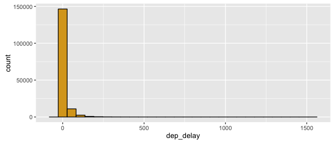

```r
qplot(x = dep_delay, data = flights,
  geom = "histogram",
  color = I("black"),
  fill = I("goldenrod"))
```

#### Exercise 2:

```r
pdx_flights <- filter(flights, origin == "PDX")
sfo_feb_flights <- filter(pdx_flights, dest == "SFO" & month == 2)
```

Use the command given to create `sfo_feb_flights`. You could either use the `dim` function from Lab 1 or `summarise`/`summarize` in the `dplyr` package.

```r
sfo_feb_flights %>% summarize(count = n())
```

```
## Source: local data frame [1 x 1]
##
##   count
##   <int>
## 1   389
```

There are 389 flights meeting this criteria.

#### Exercise 3:

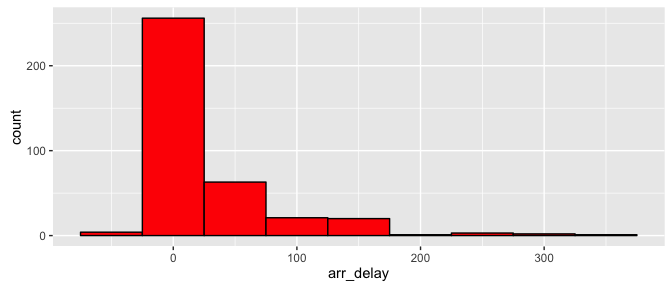

```r
qplot(x = arr_delay,
  data = sfo_feb_flights,
  binwidth = 50,
  color = I("black"),
  fill = I("red"))
```

The distribution of *arrival delays* is right-skewed. We should, therefore, use the median and IQR as summary statistics instead of measures like mean and standard deviation which are heavily influenced by outliers.

```r
sfo_feb_flights %>%
  summarize(media_ad = median(arr_delay, na.rm = TRUE),
    iqr_ad = IQR(arr_delay, na.rm = TRUE)
  )
```

```
## Source: local data frame [1 x 2]
##
##   media_ad iqr_ad
##      <dbl>  <dbl>
## 1        3   49.5
```

#### Exercise 4:

The data appears before the pipe symbol instead of the first argument in the `filter` function. Additionally, the new piping syntax allows us to chain multiple functions together so we don’t need to create the intermediate data frame of `pdx_flights` but instead pass the newly filtered data frame as the next argument to `summarise`.

#### Exercise 5:

```r
sfo_feb_flights %>%
  group_by(carrier) %>%
  summarise(median_ad = median(arr_delay, na.rm = TRUE),
            iqr_ad = IQR(arr_delay, na.rm = TRUE))
```

```
## Source: local data frame [4 x 3]
##
##   carrier median_ad iqr_ad
##     <chr>     <dbl>  <dbl>
## 1      AS      -9.0  25.00
## 2      OO       6.0  48.00
## 3      UA       8.0  53.50
## 4      VX      -1.5  45.75
```

Based on the IQR values, `UA` (United Airlines Inc.) has the most variable arrival delays.

#### Exercise 6:

```r
flights %>%
  filter(origin == "PDX") %>%
  group_by(month) %>%
  summarise(mean_dd = mean(dep_delay, na.rm = TRUE),
    median_dd = median(dep_delay, na.rm = TRUE)) %>%
  arrange(desc(mean_dd))
```

```
## Source: local data frame [12 x 3]
##
##    month   mean_dd median_dd
##    <int>     <dbl>     <dbl>
## 1     12 10.373935        -1
## 2      2  9.836729        -2
## 3      6  7.222107        -2
## 4      1  6.538767        -3
## 5      7  6.522240        -2
## 6     11  5.265949        -2
## 7      8  4.938267        -2
## 8      3  4.526680        -3
## 9      5  3.884993        -3
## 10     9  3.859645        -3
## 11    10  3.470489        -3
## 12     4  3.154549        -4
```

The month of December has the highest average (mean) departure delay. It also has the highest median departure delay. Since these distributions are very right-skewed, it makes more sense to use the median than the mean. It appears that April had the best median departure delay with flights leaving four minutes early.

### On your own:

#### 1:

```r
flights <- flights %>% mutate(avg_speed = distance / (air_time / 60))
head(flights %>% select(avg_speed))
```

```
## Source: local data frame [6 x 1]
##
##   avg_speed
##       <dbl>
## 1  476.9072
## 2  542.6190
## 3  544.7761
## 4  545.4980
## 5  432.2388
## 6  516.1607
```

Note that you need to reassign `flights` after doing the mutation here. Also note that you need to divide `air_time` by 60 to get units of mph. The first few values of this new column are provided for reference, but are not required.

#### 2:

```r
flights %>% arrange(desc(avg_speed)) %>%
  select(avg_speed, tailnum)
```

```
## Source: local data frame [162,049 x 2]
##
##    avg_speed tailnum
##        <dbl>   <chr>
## 1   652.3404  N464AS
## 2   649.3220  N462AS
## 3   634.1606  N315AS
## 4   620.5714  N768AS
## 5   617.9032  N579AS
## 6   611.8310  N3758Y
## 7   611.7757  N6714Q
## 8   611.0429  N614AS
## 9   611.0059  N559UA
## 10  610.9091  N606SK
## ..       ...     ...
```

The plane with the fastest `avg_speed` corresponds to `tailnum` N464AS. Googling this `tailnum` yields that this is an Alaska Airlines Boeing 737 [plane](https://www.planespotters.net/airframe/Boeing/737/40714/N464AS-Alaska-Airlines).

#### 3:

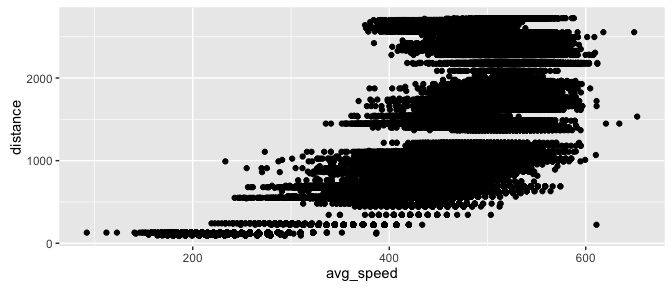

```r
qplot(x = avg_speed,
  y = distance,
  data = flights,
  geom = "point"
  )
```

Average speed appears to be positively correlated with distance traveled, but the pattern does not appear to be linear.

#### 4:

```r
flights %>%
  group_by(carrier) %>%
  summarise(max_dd = max(dep_delay, na.rm = TRUE),
    IQR_ad = IQR(arr_delay, na.rm = TRUE))
```

```
## Source: local data frame [11 x 3]
##
##    carrier max_dd IQR_ad
##      <chr>  <dbl>  <dbl>
## 1       AA   1553     23
## 2       AS    866     18
## 3       B6    365     23
## 4       DL    886     17
## 5       F9    815     20
## 6       HA    878     27
## 7       OO    677     16
## 8       UA    580     23
## 9       US    711     17
## 10      VX    358     17
## 11      WN    712     21
```

You could say a lot of other things here or just say what was actually calculated. Either is really OK based on the problem statement.

#### 5:

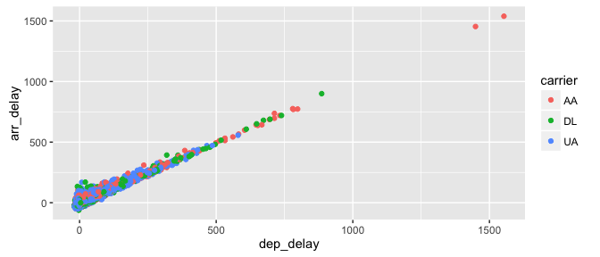

```r
sub_flights <- flights %>% filter(carrier == "AA" | carrier == "DL" | carrier == "UA")
qplot(x = dep_delay,
  y = arr_delay,
  data = sub_flights,
  color = carrier)
```

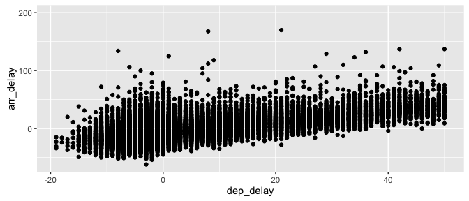

```r
qplot(x = dep_delay,
  y = arr_delay,
  data = sub_flights,
  xlim = c(min(sub_flights$dep_delay), 50),
  ylim = c(min(sub_flights$arr_delay), 200))
```

Answers will vary here. Based on this zoomed-in plot, it appears that flights are at around 50% for arriving on time at about 10 minutes of `dep_delay`.